# FinalRExercise_WuYijun

Yijun Wu

9/15/2020

# MSIA Boot Camp - Final R exercise

You’ve learned quite a lot about R in a short time. Congratulations! This exercise is designed to give you some additional practice on the material we have discussed this week while the lectures are still fresh in your mind, and to integrate different tools and skills that you have learned.

## Instructions

#### Task 1: Import your data

Read the data files `nys_schools.csv` and `nys_acs.csv` into R. These data come from two different sources: one is data on *schools* in New York state from the [New York State Department of Education](http://data.nysed.gov/downloads.php), and the other is data on *counties* from the American Communities Survey from the US Census Bureau. Review the codebook file so that you know what each variable name means in each dataset.

```r
library(here)
library(dplyr)
```

```r
library(ggplot2)
```

```r
nys_schools <- read.csv(here("data/nys_schools.csv"), stringsAsFactors = F)
nys_acs <- read.csv(here("data/nys_acs.csv"), stringsAsFactors = F)
```

#### Task 2: Explore your data

Getting to know your data is a critical part of data analysis. Take the time to explore the structure of the two dataframes you have imported. What types of variables are there? Is there any missing data? How can you tell? What else do you notice about the data?

```r
str(nys_schools)
```

```
## 'data.frame':    35663 obs. of  12 variables:
##  $ school_cd        : num  1.01e+10 1.01e+10 1.01e+10 1.01e+10 1.01e+10 ...
##  $ school_name      : chr  "MONTESSORI MAGNET SCHOOL" "MONTESSORI MAGNET SCHOOL" "MONTESSORI MAGNET SCHOOL" "MONTESSORI MAGNET SCHOOL" ...
##  $ district_name    : chr  "ALBANY CITY SCHOOL DISTRICT" "ALBANY CITY SCHOOL DISTRICT" "ALBANY CITY SCHOOL DISTRICT" "ALBANY CITY SCHOOL DISTRICT" ...
##  $ county_name      : chr  "ALBANY" "ALBANY" "ALBANY" "ALBANY" ...
##  $ region           : chr  "CAPITAL DISTRICT" "CAPITAL DISTRICT" "CAPITAL DISTRICT" "CAPITAL DISTRICT" ...
##  $ year             : int  2008 2009 2010 2011 2012 2013 2014 2015 2016 2017 ...
##  $ total_enroll     : num  316 312 300 326 294 321 335 347 366 359 ...
##  $ per_free_lunch   : num  0.33 0.32 0.26 0.22 0.31 0.25 0.35 0.22 0.29 0.26 ...
##  $ per_reduced_lunch: num  0.1 0.08 0.08 0.07 0.06 0.08 0.04 0 0.02 0.01 ...
##  $ per_lep          : num  0.01 0.02 0.03 0.03 0.03 0.03 0.06 0.06 0.05 0.07 ...
##  $ mean_ela_score   : num  658 673 670 667 670 ...
##  $ mean_math_score  : num  670 679 683 681 687 ...
```

```r
sum(is.na(nys_schools))
```

```
## [1] 0
```

```r
summary(nys_schools)
```

```
##    school_cd         school_name        district_name      county_name
##  Min.   :1.010e+10   Length:35663       Length:35663       Length:35663
##  1st Qu.:2.802e+11   Class :character   Class :character   Class :character
##  Median :3.317e+11   Mode  :character   Mode  :character   Mode  :character
##  Mean   :3.568e+11
##  3rd Qu.:4.725e+11
##  Max.   :6.808e+11
##     region               year       total_enroll    per_free_lunch
##  Length:35663       Min.   :2008   Min.   : -99.0   Min.   :-99.0000
##  Class :character   1st Qu.:2010   1st Qu.: 339.0   1st Qu.:  0.1900
##  Mode  :character   Median :2013   Median : 469.0   Median :  0.4200
##                     Mean   :2013   Mean   : 523.6   Mean   :  0.4188
##                     3rd Qu.:2015   3rd Qu.: 648.0   3rd Qu.:  0.7200
##                     Max.   :2017   Max.   :2347.0   Max.   :257.0000
##  per_reduced_lunch      per_lep          mean_ela_score  mean_math_score
##  Min.   :-99.00000   Min.   :-99.00000   Min.   :-99.0   Min.   :-99.0
##  1st Qu.:  0.03000   1st Qu.:  0.00000   1st Qu.:296.0   1st Qu.:298.0
##  Median :  0.06000   Median :  0.03000   Median :324.2   Median :330.8
##  Mean   :  0.02852   Mean   :  0.04124   Mean   :447.1   Mean   :456.0
##  3rd Qu.:  0.10000   3rd Qu.:  0.11000   3rd Qu.:666.3   3rd Qu.:683.5
##  Max.   : 53.00000   Max.   :  1.00000   Max.   :720.8   Max.   :738.7
```

“nys_schools” contains a total of 12 variables. Among these variables school id, total enrollment, percentage of free lunch, percentage of reduced price lunch, percentage of of students with limited english proficiency, mean reading score for all grades and mean math score for all grades are numbers; school name, district name, county_name and region are characters; year is integer. There is no missing value in this data frame. However, there are some abnormal values. For example, from the summary table we can see there are some negative values, while all these values should be positive. Also, for percentage of free lunch and reduced price lunch, there are values exceed 1, which are abnormal.

```r
str(nys_acs)
```

```
## 'data.frame':    496 obs. of  5 variables:
##  $ county_name            : chr  "ALBANY" "ALBANY" "ALBANY" "ALBANY" ...
##  $ year                   : int  2009 2010 2011 2012 2013 2014 2015 2016 2009 2010 ...
##  $ county_per_poverty     : num  0.118 0.119 0.121 0.124 0.123 ...
##  $ median_household_income: int  55350 56090 57715 59359 59394 59940 59887 60904 40917 41305 ...
##  $ county_per_bach        : num  0.19 0.197 0.199 0.198 0.205 ...
```

```r
sum(is.na(nys_acs))
```

```
## [1] 0
```

```r
summary(nys_acs)
```

```
##  county_name             year      county_per_poverty median_household_income
##  Length:496         Min.   :2009   Min.   :0.04689    Min.   : 33794
##  Class :character   1st Qu.:2011   1st Qu.:0.10903    1st Qu.: 46347
##  Mode  :character   Median :2012   Median :0.12884    Median : 50134
##                     Mean   :2012   Mean   :0.13085    Mean   : 54116
##                     3rd Qu.:2014   3rd Qu.:0.14929    3rd Qu.: 56448
##                     Max.   :2016   Max.   :0.29935    Max.   :102044
##  county_per_bach
##  Min.   :0.07574
##  1st Qu.:0.11018
##  Median :0.13169
##  Mean   :0.14410
##  3rd Qu.:0.17431
##  Max.   :0.31795
```

“nys_acs” contains a total of 5 variables, including county name as character, year and median household income as integers, and county per poverty and county per bachalor as numbers. There is no missing value and abnormal value in this data frame.

#### Task 3: Recoding and variable manipulation

1. Deal with missing values, which are currently coded as `-99`.
2. Create a categorical variable that groups counties into “high”, “medium”, and “low” poverty groups. Decide how you want to split up the groups and briefly explain your decision.
3. The tests that the NYS Department of Education administers changes from time to time, so scale scores are not directly comparable year-to-year. Create a new variable that is the standardized z-score for math and English Language Arts (ELA) for each year (hint: group by year and use the `scale()` function)

```r
#1. Instead of removing all rows that contains missing values, I choose to change the missing values to NA in order to keep the intergrety of the data. I also change the percentage that greater than 1 to NA.
for (i in 1: nrow(nys_schools)){
  for (j in 1: ncol(nys_schools)){
    if(nys_schools[i, j] == -99){
      nys_schools[i, j] = NA
    }
  }
}
nys_schools$per_free_lunch <- ifelse(nys_schools$per_free_lunch > 1, NA, nys_schools$per_free_lunch)
nys_schools$per_reduced_lunch <- ifelse(nys_schools$per_reduced_lunch > 1, NA, nys_schools$per_reduced_lunch)
sum(is.na(nys_schools))
```

```
## [1] 4577
```

```r
#2. I first calculate the average percentage fo poverty for each county over years. Then use quantile() to find the cutoff for 33% and 66%. Finally, I labeled the county with lowest 33% of the poverty rate as "Low", the county with the middle 33% of poverty rate as "Median", and the county with the highest 33% of the poverty rate as "High".
poverty_group <- nys_acs %>%
                 select(county_name, county_per_poverty) %>%
                 group_by(county_name) %>%
                 summarise(avg_per_poverty = mean(county_per_poverty)) %>%
                 mutate(poverty_level = case_when(avg_per_poverty <= quantile(avg_per_poverty, 0.33) ~ "Low",
                                                  avg_per_poverty > quantile(avg_per_poverty, 0.33) & avg_per_poverty <= quantile(avg_per_poverty, 0.66) ~ "Medium",
                                                  avg_per_poverty > quantile(avg_per_poverty, 0.66) ~ "High"))
```

```r
#3.
nys_schools <- nys_schools %>%
              group_by(year) %>%
              mutate(ela_z_score = scale(mean_ela_score), math_z_score = scale(mean_math_score))
```

#### Task 4: Merge datasets

Create a county-level dataset that merges variables from the schools dataset and the ACS dataset. Remember that you have learned multiple approaches on how to do this, and that you will have to decide how to summarize data when moving from the school to the county level.

```r
county_data <- nys_schools %>%
               group_by(county_name, year) %>%
               summarize(total_enroll = sum(total_enroll, na.rm = T),
                         avg_per_free_lunch = mean(per_free_lunch, na.rm = T),
                         avg_per_reduced_lunch = mean(per_reduced_lunch, na.rm = T),
                         avg_per_lep = mean(per_lep, na.rm = T),
                         avg_ela_score = mean(ela_z_score, na.rm = T),
                         avg_math_score = mean(math_z_score, na.rm = T)) %>%
               inner_join(nys_acs, by.x = c("county_name", "year"), by.y = c("name", "year")) %>%
               full_join(poverty_group, by = "county_name")
```

#### Task 5: Create summary tables

Generate tables showing the following:

1. For each county: total enrollment, percent of students qualifying for free or reduced price lunch, and percent of population in poverty.
2. For the counties with the top 5 and bottom 5 poverty rate: percent of population in poverty, percent of students qualifying for free or reduced price lunch, mean reading score, and mean math score.

```r
#1
county_data %>%
  group_by(county_name) %>%
  summarise(total_enroll = mean(total_enroll),
            per_free_reduced_lunch = mean(avg_per_free_lunch+avg_per_reduced_lunch),
            per_poverty = mean(avg_per_poverty))
```

```
## # A tibble: 62 x 4
##    county_name total_enroll per_free_reduced_lunch per_poverty
##    <chr>              <dbl>                  <dbl>       <dbl>
##  1 ALBANY            25948                   0.428       0.123
##  2 ALLEGANY           5622.                  0.520       0.151
##  3 BRONX            164189.                  0.861       0.287
##  4 BROOME            19327.                  0.469       0.159
##  5 CATTARAUGUS        9322.                  0.517       0.165
##  6 CAYUGA             5775.                  0.419       0.115
##  7 CHAUTAUQUA        13320.                  0.549       0.175
##  8 CHEMUNG            8778.                  0.489       0.149
##  9 CHENANGO           5352.                  0.551       0.145
## 10 CLINTON            7430.                  0.441       0.132
## # … with 52 more rows
```

```r
#2
summary <- county_data %>%
           group_by(county_name) %>%
           summarise(per_free_reduced_lunch = mean(avg_per_free_lunch+avg_per_reduced_lunch),
                     per_poverty = mean(avg_per_poverty),
                     mean_ela_score = mean(avg_ela_score),
                     mean_math_score = mean(avg_math_score)) %>%
           arrange(by = per_poverty)
#Counties with top 5 poverty rates
head(arrange(summary, desc(per_poverty)), 5)
```

```
## # A tibble: 5 x 5
##   county_name per_free_reduced_lunch per_poverty mean_ela_score mean_math_score
##   <chr>                        <dbl>       <dbl>          <dbl>           <dbl>
## 1 BRONX                        0.861       0.287        -0.777         -0.700
## 2 KINGS                        0.794       0.224        -0.289         -0.234
## 3 MONTGOMERY                   0.536       0.178        -0.485         -0.402
## 4 CHAUTAUQUA                   0.549       0.175        -0.235         -0.165
## 5 TOMPKINS                     0.416       0.175         0.0752        -0.00261
```

```r
#Counties with bottom 5 poverty rates
tail(arrange(summary, desc(per_poverty)), 5)
```

```
## # A tibble: 5 x 5
##   county_name per_free_reduced_lunch per_poverty mean_ela_score mean_math_score
##   <chr>                        <dbl>       <dbl>          <dbl>           <dbl>
## 1 DUTCHESS                     0.333      0.0836         0.0923         -0.0683
## 2 SARATOGA                     0.218      0.0640         0.626           0.512
## 3 SUFFOLK                      0.276      0.0619         0.374           0.317
## 4 PUTNAM                       0.146      0.0576         0.656           0.609
## 5 NASSAU                       0.225      0.0556         0.876           0.812
```

#### Task 6: Data visualization

Using `ggplot2`, visualize the following:

1. The relationship between access to free/reduced price lunch and test performance, at the *school* level.
2. Average test performance across *counties* with high, low, and medium poverty.

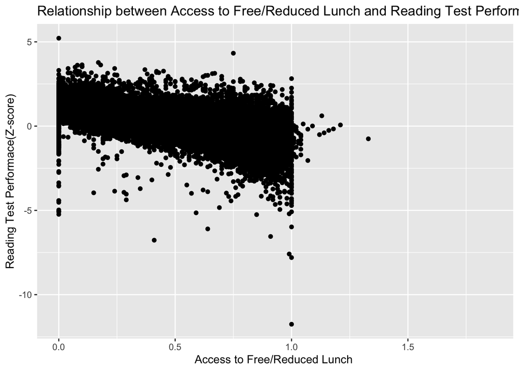

```r
# 1
nys_schools %>%
  mutate(free_reduced_price_luch = per_free_lunch+ per_reduced_lunch) %>%
  ggplot()+
  geom_point(aes(x = free_reduced_price_luch , y = ela_z_score)) +
  labs(title = "Relationship between Access to Free/Reduced Lunch and Reading Test Performance", x = "Access to Free/Reduced Lunch ", y = "Reading Test Performace(Z-score)")
```

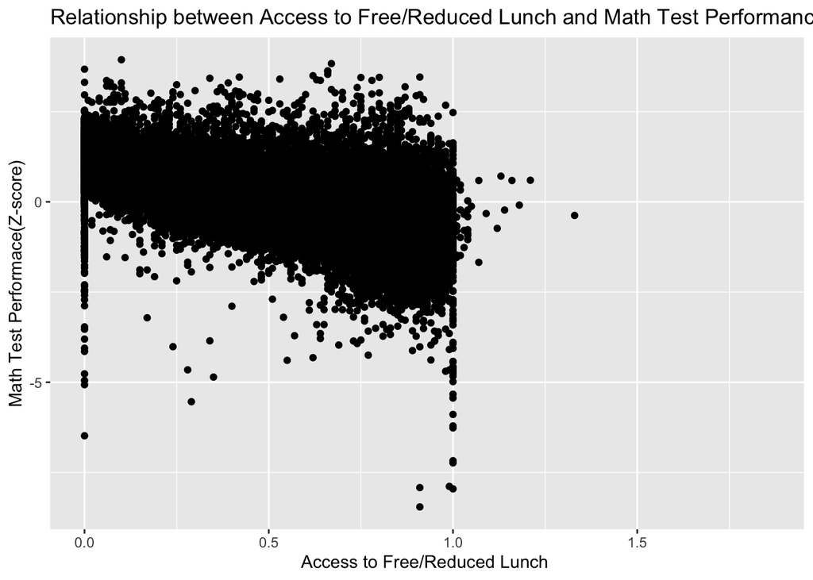

```r
nys_schools %>%
  mutate(free_reduced_price_luch = per_free_lunch+ per_reduced_lunch) %>%
  ggplot()+
  geom_point(aes(x = free_reduced_price_luch , y = math_z_score)) +
  labs(title = "Relationship between Access to Free/Reduced Lunch and Math Test Performance", x = "Access to Free/Reduced Lunch ", y = "Math Test Performace(Z-score)")
```

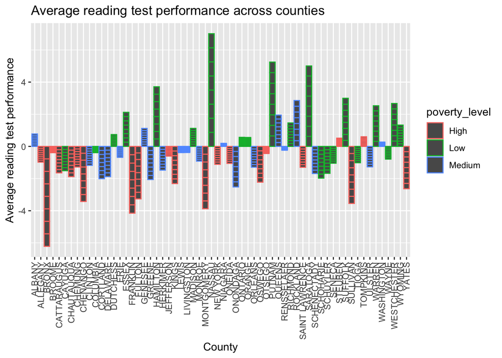

```r
#2
county_data %>%
  select(county_name, avg_ela_score, poverty_level) %>%
  group_by(county_name) %>%
  mutate(avg_test_performance = mean(avg_ela_score)) %>%
  ggplot()+
  geom_col(aes(x = county_name, y = avg_test_performance, group = poverty_level, col = poverty_level))+
  labs(title = "Average reading test performance across counties", x = "County", y = "Average reading test performance")+
  theme(axis.text.x = element_text(angle = 90, vjust = 0.5, hjust=1))
```

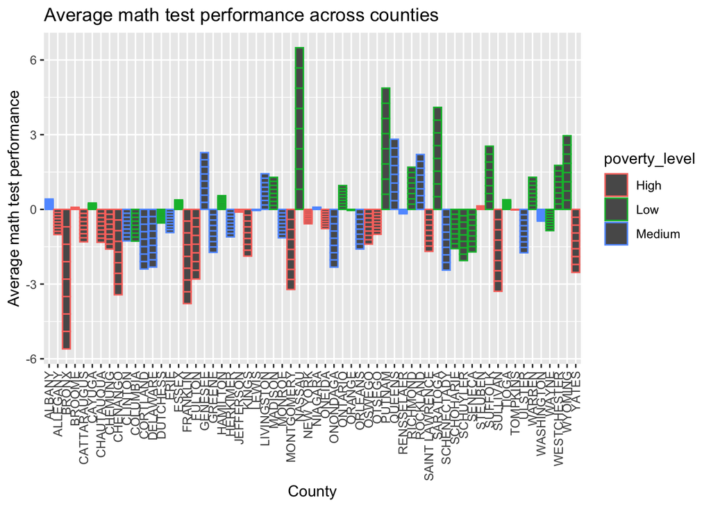

```r
county_data %>%
  select(county_name, avg_math_score, poverty_level) %>%
  group_by(county_name) %>%
  mutate(avg_test_performance = mean(avg_math_score)) %>%
  ggplot()+
  geom_col(aes(x = county_name, y = avg_test_performance, group = poverty_level, col = poverty_level))+
  labs(title = "Average math test performance across counties", x = "County", y = "Average math test performance")+
  theme(axis.text.x = element_text(angle = 90, vjust = 0.5, hjust=1))
```

#### Task 7: Answering questions

Using the skills you have learned in the past three days, tackle the following question:

> What can the data tell us about the relationship between poverty and test performance in New York public schools? Has this relationship changed over time? Is this relationship at all moderated by access to free/reduced price lunch?

You may use summary tables, statistical models, and/or data visualization in pursuing an answer to this question. Feel free to build on the tables and plots you generated above in Tasks 5 and 6.

Given the short time period, any answer will of course prove incomplete. The goal of this task is to give you some room to play around with the skills you’ve just learned. Don’t hesitate to try something even if you don’t feel comfortable with it yet. Do as much as you can in the time allotted.

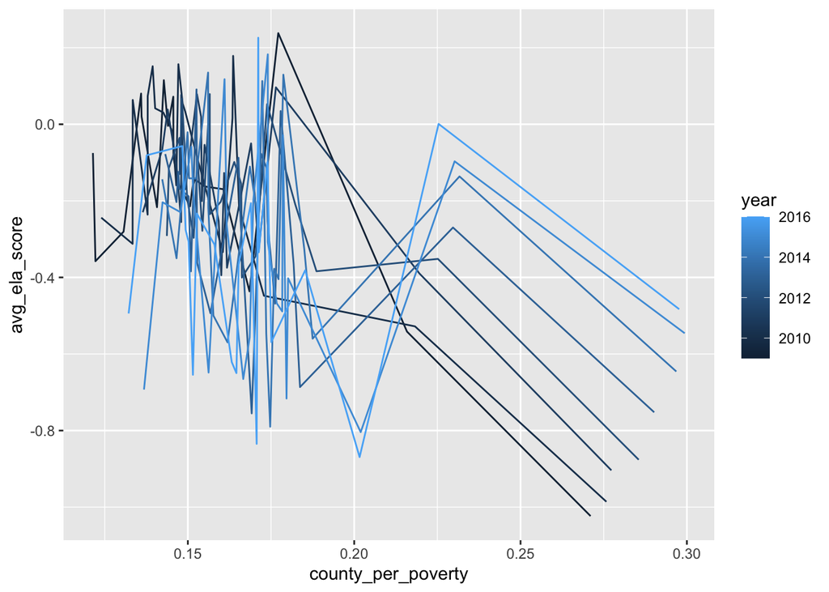

```r
county_data %>%
  filter(poverty_level == "High") %>%
  ggplot() +
  geom_line(aes(x = county_per_poverty, y = avg_ela_score, group = year, col = year))
```

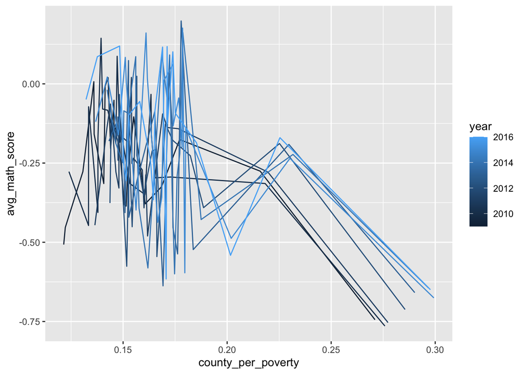

```r
county_data %>%
  filter(poverty_level == "High") %>%
  ggplot() +
  geom_line(aes(x = county_per_poverty, y = avg_math_score, group = year, col = year))
```

There is a relationship between poverty and test performace. We can see from the plots in task 6 question 2. For both reading and math test performance, counties with low poverty rates have significant better performance when compared to counties with high poverty rates.

This relationship overall has no change over time. However, from the above plot we can see that for the counties with extreme high poverty rate (percentage of poverty greater then 0.2), both reading and math scores are increasing over years. According to the plots in task 6 question 1, access to free/reduced price lunch does not seem to morderate the relationship.

## Github submission

When you have completed the exercise, save your Markdown file in the `submissions` folder of your forked repo using this naming convention: `FinalRExercise_LastnameFirstname.Rmd`. Commit changes periodically, and push commits when you are done.

You can optionally create a pull request to submit this file (and other exercise files from the bootcamp sessions) to the base repo that lives in the MSiA organization. If you would like to do this, make sure that all new files you have created are in the `submissions` folder, and then create a pull request that asks to merge changes from your forked repo to the base repo.

## Reminders

- Remember to **load necessary packages**.
- Remember to **comment extensively** in your code. Since you will be working in an RMarkdown file, you can describe your workflow in the text section. But you should also comment within all of your code chunks.
- Attempt to knit your Markdown file into HTML format before committing it to Github. Troubleshoot any errors with the knit process by checking the lines referred to in the error messages.